# ES Core Relative Allocation — Strategy Document

RR Capital | Version 1.0 | June 2026

## Instrument universe and core design

The strategy trades ten futures contracts: ES (S&P 500), NQ (Nasdaq-100), RTY (Russell 2000), GC (Gold), SI (Silver), ZN (10-year Treasury), ZT (2-year Treasury), ZF (5-year Treasury), ZB (U.S. Treasury Bond), and BTC (Bitcoin). All are USD-denominated and trade on regulated U.S. exchanges.

The organizing principle is that each instrument represents a distinct economic exposure that belongs in a long-term portfolio allocation. Short-term positioning vehicles and commodity sub-sector contracts were excluded because they are not designed to be held as long-term risk premia.

The three equity contracts each represent a meaningfully different segment of the U.S. economy. ES provides exposure to the broad U.S. equity market — large and mid-cap businesses across all sectors, weighted by market capitalization. NQ concentrates exposure in the Nasdaq-100, heavily weighted toward technology, software, semiconductors, and other innovation-driven businesses with long-duration earnings profiles. RTY provides exposure to U.S. small-cap domestically oriented businesses whose returns are more sensitive to domestic economic conditions and less correlated with global growth cycles than large-cap indices.

Gold and silver provide real asset exposure — stores of value whose behavior differs from financial assets, particularly during currency stress and late-cycle environments.

The four Treasury contracts span the U.S. yield curve. ZT (2-year), ZF (5-year), ZN (10-year), and ZB (30-year Bond) provide differentiated duration exposure. Short-end rates are more sensitive to Federal Reserve policy expectations; the long end responds to inflation expectations, term premium, and risk-off demand. Holding multiple points on the curve allows the signal to rotate toward the tenor that is outperforming on a risk-adjusted basis at any given time.

Bitcoin provides exposure to a distinct return source — a non-sovereign, fixed-supply digital asset with returns driven by adoption dynamics, risk appetite, and regulatory developments that are largely uncorrelated with traditional financial markets over multi-year horizons. BTC futures have traded on the CME since December 2017, so the full backtest history is available only from that date; earlier years treat BTC as absent from the eligible universe.

**Why ES is the core.** U.S. large-cap equity has been the most reliably positive long-run risk premium available to investors. ES is the benchmark against which every alternative’s relative performance is assessed: the allocation signal measures how consistently each alternative is outperforming the equity core on a risk-adjusted basis. The permanent equity core ensures the strategy participates in the growth regime that historically accounts for the majority of compounded long-run return. The objective is strong long-run compounding — the design accepts bear market drawdowns as the necessary cost of sustained equity participation.

## Strategy design and the role of leverage

The ES Core Relative Allocation maintains a permanent allocation to ES as the equity core and dynamically allocates up to 50 percent of the portfolio to the nine alternative instruments based on their risk-adjusted performance relative to ES.

The allocation process operates at daily frequency. The signal evaluates each instrument’s recent risk-adjusted performance history and determines both the size of each position and the proportion of the portfolio it receives. Strong-performing alternatives receive larger allocations; weak-performing alternatives are reduced toward zero. The ES core always holds the residual weight — ensuring net long equity exposure at all times. Allocations are smoothed to reduce unnecessary turnover, and a no-trade band prevents rebalancing when signal changes are small relative to the existing position.

The strategy incorporates a dynamic volatility targeting mechanism. Position sizes are scaled in proportion to recent measured downside volatility, so that each instrument contributes a roughly consistent level of realized risk to the portfolio regardless of its current volatility regime. When an instrument becomes more volatile its position size is reduced; when it becomes less volatile the position expands.

Leverage is not an optional feature — it is structurally necessary. Futures contracts require margin rather than full capital, and the volatility targeting mechanism systematically determines how much notional exposure each dollar of capital should support. In high-conviction, low-volatility environments the strategy runs above 1x notional leverage; in uncertain or high-volatility environments it contracts toward or below 1x. The objective of dynamic leverage is not to maximize return at any given moment but to maintain a consistent risk profile across changing conditions.

Specific signal parameters are not disclosed here. Publishing exact parameters would accelerate their decay as similar strategies adopted the same values.

## Backtest results

**Warning**

The figures in this section are **hypothetical backtested performance** — they were not achieved by any investor. Backtested results have inherent limitations: they are computed with the benefit of hindsight, parameters were chosen with knowledge of the historical data, and actual trading would encounter costs, liquidity constraints, and execution friction not fully captured in simulation. Past hypothetical performance is not a reliable indicator of future results.

The strategy was backtested from 2000 to June 2026 using Norgate Data individual contract price series with explicit roll scheduling. All signals are lagged one day to prevent look-ahead bias. Commission of $5 per contract and one tick of slippage per side are charged on every trade. The analysis start date is 2001-09-19, reflecting the warm-up period required for the longest signal windows to initialize. BTC is excluded from the universe prior to December 2017 when CME contracts became available.

| Metric | Strategy | ES benchmark |
| --- | --- | --- |
| Total return | 3,727% | 575% |
| CAGR | 15.9% | 8.0% |
| Ann. volatility | 20.8% | 18.9% |
| Sharpe ratio | **0.813** | 0.504 |
| Sortino ratio | **1.120** | 0.711 |
| Max drawdown | **−27.8%** | −53.8% |

A note on the source of outperformance: a substantial portion of the return difference versus the unlevered ES benchmark reflects dynamic leverage rather than the tactical rotation signal specifically. The signal’s independent contribution is real but smaller than the gross outperformance against buy-and-hold implies. The strategy takes full equity drawdowns during fast bear markets — this is a structural feature, not a parameter deficiency.

## Parameter robustness

A strategy that performs well only at its exact design parameters is not a robust investment program but a result specific to one set of choices.

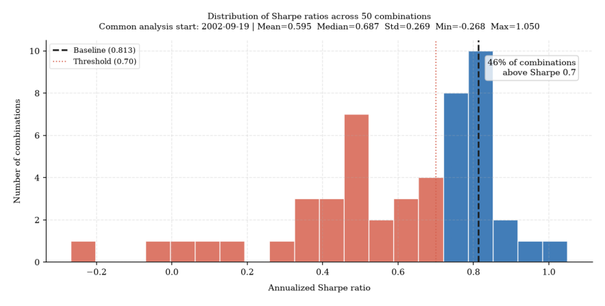

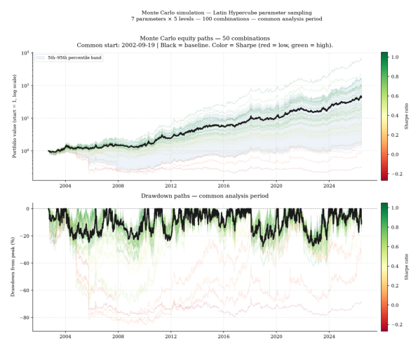

## Volatility target sensitivity

The volatility targeting mechanism caps leverage by bounding the target downside volatility. The upper bound is the single most impactful lever for controlling the strategy’s risk profile: a lower cap means less leverage and more conservative sizing in favorable conditions; a higher cap allows the mechanism to scale more aggressively when volatility is low.

This section tests the baseline cap of 0.20 (annualized downside volatility) against four alternatives at ±25% and ±50%. All other parameters are held at baseline.

| Vol target cap | Sharpe | CAGR | Max DD | Ann. Vol |
| --- | --- | --- | --- | --- |
| 0.10 (−50%) | 0.489 | 7.2% | −26.8% | 14.7% |
| 0.15 (−25%) | 0.572 | 10.5% | −35.1% | 18.4% |
| **0.20 (baseline)** | **0.770** | **16.0%** | **−27.8%** | **20.8%** |
| 0.25 (+25%) | 0.862 | 20.0% | −27.8% | 23.2% |
| 0.30 (+50%) | 0.912 | 23.0% | −33.9% | 25.3% |

The Sharpe ratio increases monotonically with the cap across the full tested range. Higher caps allow the volatility-targeting mechanism to scale more aggressively in low-volatility environments, producing meaningfully higher CAGR at the cost of proportionally higher realised volatility. Notably, the worst drawdown does not increase monotonically — the 0.20 and 0.25 levels produce identical maximum drawdowns of −27.8%, while the 0.15 level actually produces a worse drawdown (−35.1%) than the baseline despite lower average leverage, reflecting the impact of unfavourable timing when the cap binds at an inopportune moment.

The baseline of 0.20 is conservative relative to what the historical data supports. This was chosen deliberately: a margin of safety between the backtested optimum and the live parameter is standard practice for systematic programs, reflecting the difference between in-sample and out-of-sample performance. Whether a higher cap would outperform in live deployment depends on whether the historical relationship between volatility and subsequent returns persists — which cannot be known in advance.

The bar chart below compares the four key metrics across all five levels. The equity paths and drawdown chart illustrates how the growth trajectory and risk profile shift as the cap rises.

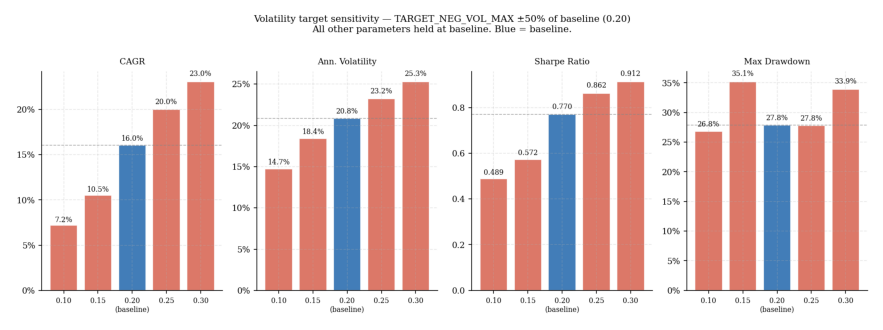

Performance metrics across five volatility target cap levels (±50% of baseline 0.20). Blue = baseline. Source: Author calculations using Norgate Data.

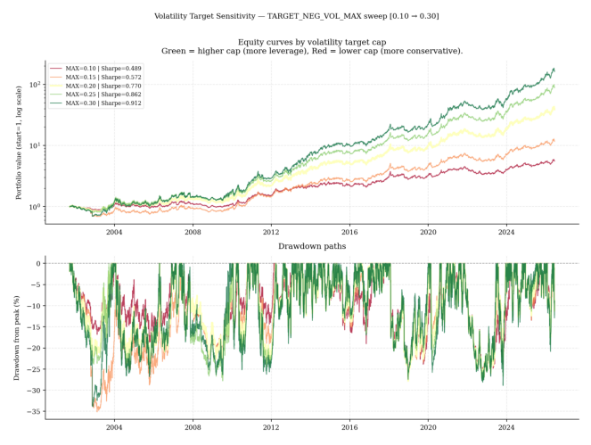

Equity curves and drawdown paths across volatility target cap levels. Green = higher cap (more aggressive), Red = lower cap (more conservative). Source: Author calculations.

## Regime decomposition

Each trading day in the backtest is classified into one of four regimes using publicly available data: Equity Bear (trailing 12-month market return below −10% or VIX above 30), Inflation (CPI year-on-year above 4% and rising), Equity Bull (trailing 12-month return above 15%), and Neutral (all remaining days). The priority ordering ensures that bear conditions are correctly identified even when they coincide with elevated inflation.

The timeline chart below shows how regimes are distributed across the full backtest period, alongside the underlying macro indicators used for classification.

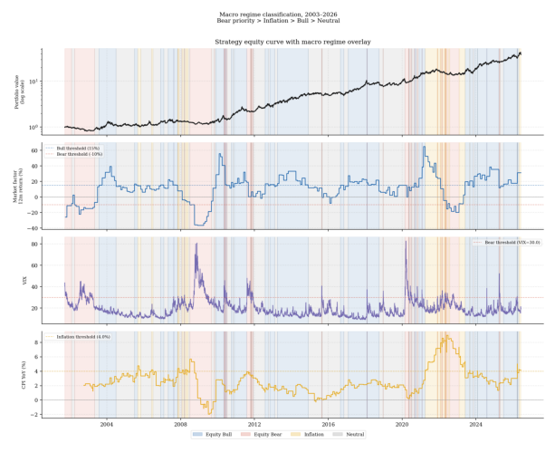

[output not shown]

The strategy’s return is concentrated in Equity Bull periods (Sharpe 1.48) and Neutral periods (Sharpe 1.07), which together account for 74% of the sample. The Equity Bear regime is the strategy’s primary structural weakness — during 1,051 bear days the strategy lost at an annualized rate of −24.5%. This is a direct consequence of the backward-looking signal design: the allocation mechanism requires sustained relative underperformance before it reduces equity exposure materially. The strategy is not a drawdown-defense product.

The chart below summarises Sharpe ratio, CAGR, maximum drawdown, and win rate for each regime.

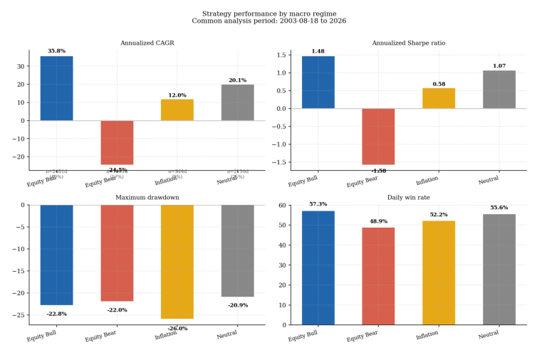

Strategy performance by macro regime: annualized CAGR, Sharpe ratio, maximum drawdown, and daily win rate. Source: FRED, author calculations.

## Live deployment

**Warning**

The IBKR forward test referenced here is days old at the time of writing. It is not evidence of strategy validity. The paper’s own standard for meaningful evaluation is a minimum of 24 months across at least two distinct macro regimes.

The ES Core Relative Allocation is deployed live at Interactive Brokers as the complete reference implementation — the full ten-instrument universe, running the same logic as the backtested engine with real capital. This forward test began in June 2026.

A forward test of days provides no statistical information about performance quality. Substantive evaluation requires accumulation of out-of-sample data across multiple macro regimes. The paper’s own standard is 24 months of live data spanning at least two distinct regime episodes.

**External participation.** Outside participation is currently available only through the Darwinex Zero structure under the ticker [UJNU](https://www.darwinexzero.com/darwin/UJNU/performance), which has operated since 5 March 2026. The Darwinex Zero implementation uses a constrained instrument universe and applies a VaR normalization filter that standardizes the published track record to a target monthly VaR of 6.5%. The published DARWIN performance will therefore differ from the underlying strategy returns and from the IBKR reference implementation whenever the strategy’s actual volatility diverges materially from that target.